# Tugas Praktikum Pertemuan 2 MPDW

```r
library(readxl)
library(lmtest)
library(ggplot2)

if (!requireNamespace("orcutt", quietly = TRUE)) {
  install.packages("orcutt", repos = "https://cloud.r-project.org")
}
library(orcutt)
```

```r
hildreth_lu <- function(y, x, rho_range = seq(-0.99, 0.99, by = 0.01)) {
  n <- length(y)
  sse <- numeric(length(rho_range))

  for (i in seq_along(rho_range)) {
    rho <- rho_range[i]
    y_star <- y[-1] - rho * y[-n]
    x_star <- x[-1] - rho * x[-n]
    model_star <- lm(y_star ~ x_star)
    sse[i] <- sum(residuals(model_star)^2)
  }

  best_rho <- rho_range[which.min(sse)]

  y_star <- y[-1] - best_rho * y[-n]
  x_star <- x[-1] - best_rho * x[-n]
  model_final <- lm(y_star ~ x_star)

  intercept <- unname(coef(model_final)[1] / (1 - best_rho))
  slope     <- unname(coef(model_final)[2])

  list(
    rho_optimum   = best_rho,
    sse_grid      = data.frame(rho = rho_range, SSE = sse),
    model_transformasi = model_final,
    koefisien_asli = c(intercept = intercept, slope = slope)
  )
}
```

# Soal 1: Market Share dan Price

## Eksplorasi Data

```r
soal1 <- read_excel("D:\\SEM 5\\MPDW\\data_praktikum2.xlsx", sheet = "Soal1_MarketShare_Price")
str(soal1)
```

```
## tibble [20 × 3] (S3: tbl_df/tbl/data.frame)
##  $ Period      : num [1:20] 1 2 3 4 5 6 7 8 9 10 ...
##  $ Market_share: num [1:20] 3.63 4.2 3.33 4.54 2.89 4.87 4.9 5.29 6.18 7.2 ...
##  $ Price       : num [1:20] 0.97 0.95 0.99 0.91 0.98 0.9 0.89 0.86 0.85 0.82 ...
```

```r
summary(soal1)
```

```
##      Period       Market_share       Price
##  Min.   : 1.00   Min.   :2.890   Min.   :0.7600
##  1st Qu.: 5.75   1st Qu.:4.787   1st Qu.:0.7900
##  Median :10.50   Median :6.490   Median :0.8300
##  Mean   :10.50   Mean   :6.215   Mean   :0.8520
##  3rd Qu.:15.25   3rd Qu.:7.982   3rd Qu.:0.9025
##  Max.   :20.00   Max.   :8.650   Max.   :0.9900
```

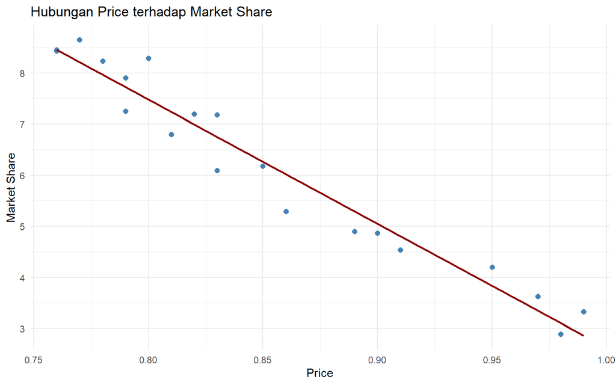

```r
ggplot(soal1, aes(x = Price, y = Market_share)) +
  geom_point(color = "steelblue", size = 2) +
  geom_smooth(method = "lm", se = FALSE, color = "darkred") +
  labs(title = "Hubungan Price terhadap Market Share",
       x = "Price", y = "Market Share") +
  theme_minimal()
```

## Model Regresi OLS

```r
model1 <- lm(Market_share ~ Price, data = soal1)
summary(model1)
```

```
##
## Call:
## lm(formula = Market_share ~ Price, data = soal1)
##
## Residuals:
##      Min       1Q   Median       3Q      Max
## -0.73068 -0.29764 -0.00966  0.30224  0.81193
##
## Coefficients:
##             Estimate Std. Error t value Pr(>|t|)
## (Intercept)   26.910      1.110   24.25 3.39e-15 ***
## Price        -24.290      1.298  -18.72 3.02e-13 ***
## ---
## Signif. codes:  0 '***' 0.001 '**' 0.01 '*' 0.05 '.' 0.1 ' ' 1
##
## Residual standard error: 0.4287 on 18 degrees of freedom
## Multiple R-squared:  0.9511, Adjusted R-squared:  0.9484
## F-statistic: 350.3 on 1 and 18 DF,  p-value: 3.019e-13
```

## Pemeriksaan Asumsi Autokorelasi

### Plot Sisaan

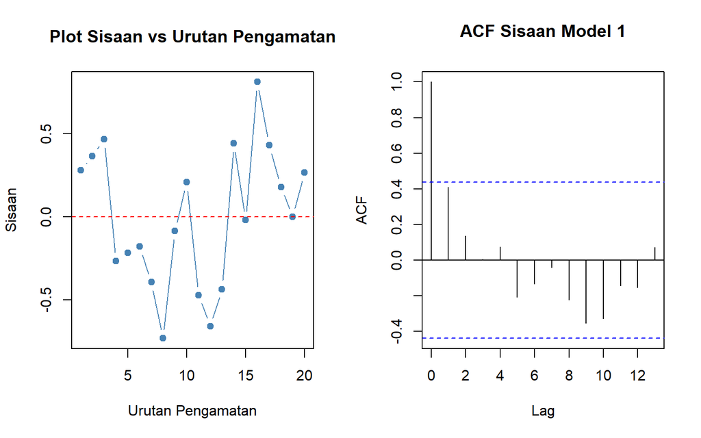

```r
par(mfrow = c(1, 2))
plot(residuals(model1), type = "b", pch = 19, col = "steelblue",
     main = "Plot Sisaan vs Urutan Pengamatan",
     xlab = "Urutan Pengamatan", ylab = "Sisaan")
abline(h = 0, col = "red", lty = 2)

acf(residuals(model1), main = "ACF Sisaan Model 1")
```

```r
par(mfrow = c(1, 1))
```

### Uji Durbin-Watson

```r
dwtest(model1)
```

```
##
##  Durbin-Watson test
##
## data:  model1
## DW = 1.1358, p-value = 0.009813
## alternative hypothesis: true autocorrelation is greater than 0
```

**Interpretasi:** Diperoleh $DW = 1.1358$ dengan *p-value* $= 0.009813$. Nilai ini di bawah $d_L = 1.20$ (tabel DW, $n=20$, $k=1$, $\alpha=5\%$) dan *p-value* $< 0.05$, sehingga tolak $H_0$: terdapat autokorelasi **positif** pada sisaan. Perlu dilakukan penanganan.

## Penanganan Autokorelasi

### Metode Cochrane-Orcutt

```r
model1_co <- cochrane.orcutt(model1)
model1_co
```

```
## Cochrane-orcutt estimation for first order autocorrelation
##
## Call:
## lm(formula = Market_share ~ Price, data = soal1)
##
##  number of interaction: 8
##  rho 0.425232
##
## Durbin-Watson statistic
## (original):    1.13582 , p-value: 9.813e-03
## (transformed): 1.95804 , p-value: 4.151e-01
##
##  coefficients:
## (Intercept)       Price
##    26.72209   -24.08413
```

```r
# Uji Durbin-Watson ulang setelah penanganan Cochrane-Orcutt
dwtest_co1 <- model1_co$DW
dwtest_co1
```

```
##          DW                      DW
## 1.135816105 0.009813346 1.958041497 0.415141765
```

### Metode Hildreth-Lu

```r
model1_hl <- hildreth_lu(soal1$Market_share, soal1$Price)

cat("Rho optimum (Hildreth-Lu):", model1_hl$rho_optimum, "\n")
```

```
## Rho optimum (Hildreth-Lu): 0.43
```

```r
model1_hl$koefisien_asli
```

```
## intercept     slope
##  26.70977 -24.06941
```

```r
summary(model1_hl$model_transformasi)
```

```
##
## Call:
## lm(formula = y_star ~ x_star)
##
## Residuals:
##     Min      1Q  Median      3Q     Max
## -0.5532 -0.2512 -0.0552  0.2493  0.8302
##
## Coefficients:
##             Estimate Std. Error t value Pr(>|t|)
## (Intercept)  15.2246     0.9349   16.29 8.35e-12 ***
## x_star      -24.0694     1.9474  -12.36 6.40e-10 ***
## ---
## Signif. codes:  0 '***' 0.001 '**' 0.01 '*' 0.05 '.' 0.1 ' ' 1
##
## Residual standard error: 0.3955 on 17 degrees of freedom
## Multiple R-squared:  0.8999, Adjusted R-squared:  0.894
## F-statistic: 152.8 on 1 and 17 DF,  p-value: 6.396e-10
```

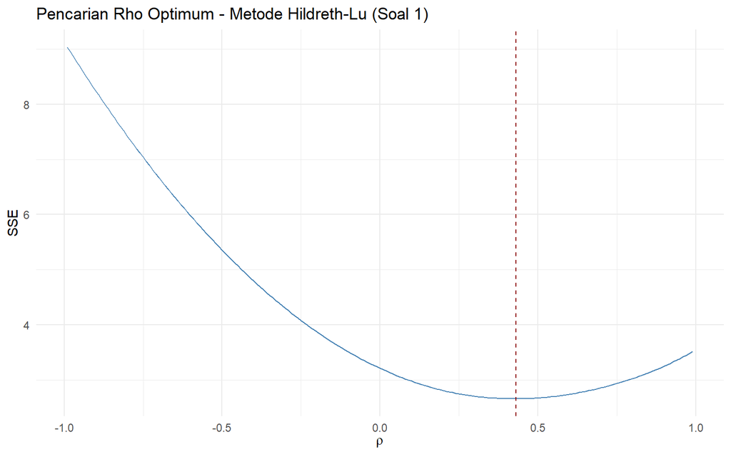

```r
ggplot(model1_hl$sse_grid, aes(x = rho, y = SSE)) +
  geom_line(color = "steelblue") +
  geom_vline(xintercept = model1_hl$rho_optimum, color = "darkred", linetype = "dashed") +
  labs(title = "Pencarian Rho Optimum - Metode Hildreth-Lu (Soal 1)",
       x = expression(rho), y = "SSE") +
  theme_minimal()
```

```r
dwtest(model1_hl$model_transformasi)
```

```
##
##  Durbin-Watson test
##
## data:  model1_hl$model_transformasi
## DW = 1.9656, p-value = 0.4228
## alternative hypothesis: true autocorrelation is greater than 0
```

### Perbandingan Model

```r
# Ambil DW & p-value tiap model
dw_awal <- dwtest(model1)
dw_co   <- dwtest(model1_co)          # atau dwtest(model1CO) kalau pakai orcutt::cochrane.orcutt
dw_hl   <- dwtest(model1_hl$model_transformasi)

tabel_dw <- data.frame(
  Metode     = c("OLS (awal)", "Cochrane-Orcutt", "Hildreth-Lu"),
  Rho        = c(NA, model1_co$rho, model1_hl$rho_optimum),
  DW         = c(dw_awal$statistic, dw_co$statistic, dw_hl$statistic),
  p_value    = c(dw_awal$p.value, dw_co$p.value, dw_hl$p.value),
  Kesimpulan = c(
    ifelse(dw_awal$p.value < 0.05, "Ada autokorelasi", "Tidak ada autokorelasi"),
    ifelse(dw_co$p.value   < 0.05, "Ada autokorelasi", "Tidak ada autokorelasi"),
    ifelse(dw_hl$p.value   < 0.05, "Ada autokorelasi", "Tidak ada autokorelasi")
  )
)

tabel_dw
```

```
##            Metode       Rho       DW     p_value             Kesimpulan
## 1      OLS (awal)        NA 1.135816 0.009813346       Ada autokorelasi
## 2 Cochrane-Orcutt 0.4252321 1.958041 0.415141765 Tidak ada autokorelasi
## 3     Hildreth-Lu 0.4300000 1.965564 0.422831364 Tidak ada autokorelasi
```

# Soal 2: Sales dan Advertising

## Eksplorasi Data

```r
soal2 <- read_excel("D:\\SEM 5\\MPDW\\data_praktikum2.xlsx", sheet = "Soal2_Sales_Advertising")
str(soal2)
```

```
## tibble [40 × 3] (S3: tbl_df/tbl/data.frame)
##  $ Year       : num [1:40] 1975 1976 1977 1978 1979 ...
##  $ Sales      : num [1:40] 11.7 12 12.3 12.8 13.1 13.6 13.9 14.4 14.7 15.3 ...
##  $ Advertising: num [1:40] 9.4 9.6 10 10.4 10.8 10.9 11.7 12.2 12.5 12.9 ...
```

```r
summary(soal2)
```

```
##       Year          Sales        Advertising
##  Min.   :1975   Min.   :11.70   Min.   : 9.40
##  1st Qu.:1985   1st Qu.:15.45   1st Qu.:12.97
##  Median :1994   Median :17.90   Median :15.90
##  Mean   :1994   Mean   :17.13   Mean   :15.72
##  3rd Qu.:2004   3rd Qu.:19.30   3rd Qu.:18.55
##  Max.   :2014   Max.   :21.00   Max.   :22.10
```

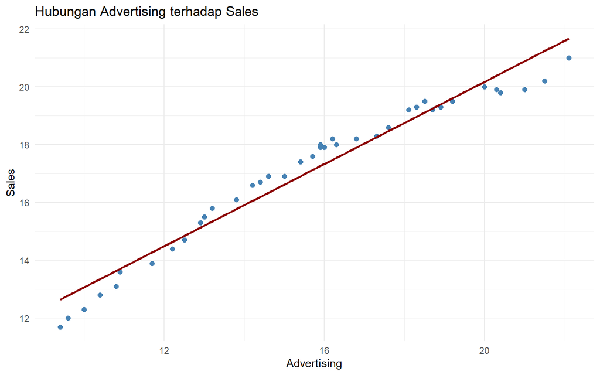

```r
ggplot(soal2, aes(x = Advertising, y = Sales)) +
  geom_point(color = "steelblue", size = 2) +
  geom_smooth(method = "lm", se = FALSE, color = "darkred") +
  labs(title = "Hubungan Advertising terhadap Sales",
       x = "Advertising", y = "Sales") +
  theme_minimal()
```

## Model Regresi OLS

```r
model2 <- lm(Sales ~ Advertising, data = soal2)
summary(model2)
```

```
##
## Call:
## lm(formula = Sales ~ Advertising, data = soal2)
##
## Residuals:
##      Min       1Q   Median       3Q      Max
## -1.03758 -0.40343  0.08933  0.45674  0.74036
##
## Coefficients:
##             Estimate Std. Error t value Pr(>|t|)
## (Intercept)  5.96513    0.38092   15.66   <2e-16 ***
## Advertising  0.71035    0.02365   30.04   <2e-16 ***
## ---
## Signif. codes:  0 '***' 0.001 '**' 0.01 '*' 0.05 '.' 0.1 ' ' 1
##
## Residual standard error: 0.527 on 38 degrees of freedom
## Multiple R-squared:  0.9596, Adjusted R-squared:  0.9585
## F-statistic: 902.3 on 1 and 38 DF,  p-value: < 2.2e-16
```

## Pemeriksaan Asumsi Autokorelasi

### Plot Sisaan

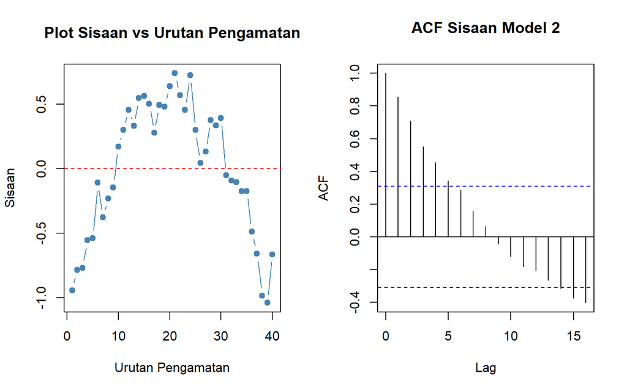

```r
par(mfrow = c(1, 2))
plot(residuals(model2), type = "b", pch = 19, col = "steelblue",
     main = "Plot Sisaan vs Urutan Pengamatan",
     xlab = "Urutan Pengamatan", ylab = "Sisaan")
abline(h = 0, col = "red", lty = 2)

acf(residuals(model2), main = "ACF Sisaan Model 2")
```

```r
par(mfrow = c(1, 1))
```

### Uji Durbin-Watson

```r
dwtest(model2)
```

```
##
##  Durbin-Watson test
##
## data:  model2
## DW = 0.16204, p-value < 2.2e-16
## alternative hypothesis: true autocorrelation is greater than 0
```

**Interpretasi:** Diperoleh $DW = 0.16204$ dengan *p-value* $< 2.2\times10^{-16}$. Nilai ini jauh di bawah $d_L = 1.44$ (tabel DW, $n=40$, $k=1$, $\alpha=5\%$) dan *p-value* $< 0.05$, sehingga tolak $H_0$: terdapat autokorelasi **positif** yang sangat kuat pada sisaan. Perlu dilakukan penanganan.

## Penanganan Autokorelasi

### Metode Cochrane-Orcutt

```r
model2_co <- cochrane.orcutt(model2)
model2_co
```

```
## Cochrane-orcutt estimation for first order autocorrelation
##
## Call:
## lm(formula = Sales ~ Advertising, data = soal2)
##
##  number of interaction: 39
##  rho 0.903123
##
## Durbin-Watson statistic
## (original):    0.16204 , p-value: 8.935e-20
## (transformed): 1.93925 , p-value: 3.78e-01
##
##  coefficients:
## (Intercept) Advertising
##   10.252375    0.488489
```

```r
dwtest_co2 <- model2_co$DW
dwtest_co2
```

```
##           DW                        DW
## 1.620428e-01 8.935306e-20 1.939254e+00 3.780214e-01
```

### Metode Hildreth-Lu

```r
model2_hl <- hildreth_lu(soal2$Sales, soal2$Advertising)

cat("Rho optimum (Hildreth-Lu):", model2_hl$rho_optimum, "\n")
```

```
## Rho optimum (Hildreth-Lu): 0.9
```

```r
model2_hl$koefisien_asli
```

```
##  intercept      slope
## 10.1309787  0.4935821
```

```r
summary(model2_hl$model_transformasi)
```

```
##
## Call:
## lm(formula = y_star ~ x_star)
##
## Residuals:
##     Min      1Q  Median      3Q     Max
## -0.3749 -0.1461  0.0148  0.1057  0.4496
##
## Coefficients:
##             Estimate Std. Error t value Pr(>|t|)
## (Intercept)  1.01310    0.14198   7.135 1.87e-08 ***
## x_star       0.49358    0.07379   6.689 7.38e-08 ***
## ---
## Signif. codes:  0 '***' 0.001 '**' 0.01 '*' 0.05 '.' 0.1 ' ' 1
##
## Residual standard error: 0.1868 on 37 degrees of freedom
## Multiple R-squared:  0.5474, Adjusted R-squared:  0.5351
## F-statistic: 44.74 on 1 and 37 DF,  p-value: 7.382e-08
```

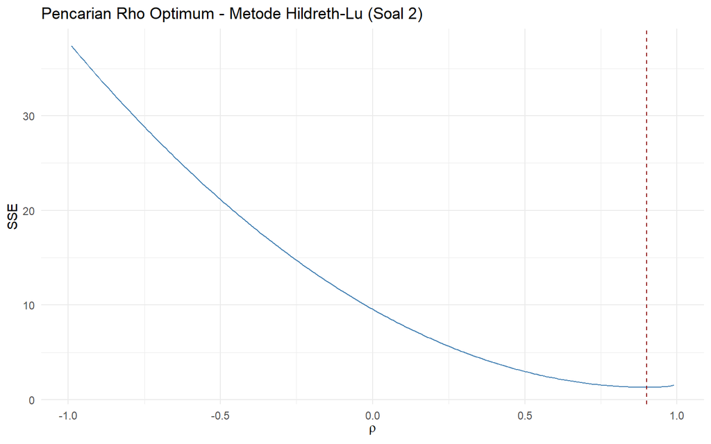

```r
ggplot(model2_hl$sse_grid, aes(x = rho, y = SSE)) +
  geom_line(color = "steelblue") +
  geom_vline(xintercept = model2_hl$rho_optimum, color = "darkred", linetype = "dashed") +
  labs(title = "Pencarian Rho Optimum - Metode Hildreth-Lu (Soal 2)",
       x = expression(rho), y = "SSE") +
  theme_minimal()
```

```r
dwtest(model2_hl$model_transformasi)
```

```
##
##  Durbin-Watson test
##
## data:  model2_hl$model_transformasi
## DW = 1.9402, p-value = 0.3782
## alternative hypothesis: true autocorrelation is greater than 0
```

### Perbandingan Model

```r
dw_awal2 <- dwtest(model2)
dw_co2   <- dwtest(model2_co)
dw_hl2   <- dwtest(model2_hl$model_transformasi)

tabel_dw2 <- data.frame(
  Metode     = c("OLS (awal)", "Cochrane-Orcutt", "Hildreth-Lu"),
  Rho        = c(NA, model2_co$rho, model2_hl$rho_optimum),
  DW         = c(dw_awal2$statistic, dw_co2$statistic, dw_hl2$statistic),
  p_value    = c(dw_awal2$p.value, dw_co2$p.value, dw_hl2$p.value),
  Kesimpulan = c(
    ifelse(dw_awal2$p.value < 0.05, "Ada autokorelasi", "Tidak ada autokorelasi"),
    ifelse(dw_co2$p.value   < 0.05, "Ada autokorelasi", "Tidak ada autokorelasi"),
    ifelse(dw_hl2$p.value   < 0.05, "Ada autokorelasi", "Tidak ada autokorelasi")
  )
)

tabel_dw2
```

```
##            Metode       Rho        DW      p_value             Kesimpulan
## 1      OLS (awal)        NA 0.1620428 8.935306e-20       Ada autokorelasi
## 2 Cochrane-Orcutt 0.9031233 1.9392537 3.780214e-01 Tidak ada autokorelasi
## 3     Hildreth-Lu 0.9000000 1.9401651 3.781665e-01 Tidak ada autokorelasi
```

**Interpretasi:** Setelah penanganan, nilai DW naik dari $0.1620$ menjadi $1.939$ (Cochrane-Orcutt) dan $1.940$ (Hildreth-Lu), dengan *p-value* masing-masing $0.378$ dan $0.378$ (keduanya > 0.05). Artinya autokorelasi pada sisaan **sudah teratasi** pada kedua metode.

# Kesimpulan

Model regresi awal pada kedua soal melanggar asumsi non-autokorelasi: Model 1 (Market Share ~ Price) memiliki $DW = 1.1358$ (*p-value* $= 0.0098$) dan Model 2 (Sales ~ Advertising) memiliki $DW = 0.1620$ (*p-value* $< 2.2\times10^{-16}$), keduanya menunjukkan autokorelasi **positif** pada sisaan.

Setelah dilakukan penanganan dengan metode **Cochrane-Orcutt** dan **Hildreth-Lu**, autokorelasi pada kedua model berhasil diatasi. Nilai DW naik mendekati 2 dan *p-value* menjadi tidak signifikan (> 0.05) pada kedua metode:

- Model 1: DW naik menjadi $1.958$ (CO) dan $1.966$ (HL), rho $\approx 0.43$.
- Model 2: DW naik menjadi $1.939$ (CO) dan $1.940$ (HL), rho $\approx 0.90$.

Kedua metode penanganan menghasilkan nilai rho dan koefisien regresi yang hampir identik pada masing-masing model, menunjukkan bahwa **Cochrane-Orcutt dan Hildreth-Lu sama-sama efektif** dalam mengatasi autokorelasi pada data ini, sehingga model hasil penanganan lebih valid digunakan untuk inferensi dibandingkan model OLS awal.